# ClinReport R package

Jean-Francois COLLIN

2019-03-07

## Get started

Start by loading all usual libraries.

```r
library(ClinReport)
library(officer)
library(flextable)
library(dplyr)
library(reshape2)
library(nlme)
library(emmeans)
library(car)
```

Load your data.

```r
# We will use fake data
data(data)
print(head(data))
```

```
#>    y_numeric y_logistic y_poisson   baseline   VAR GROUP TIMEPOINT SUBJID
#> 1 -0.4203490          1         5 -0.4203490 Cat 1     A        D0 Subj 1
#> 2 -0.1570941          1         5 -0.1570941 Cat 2     A        D0 Subj 1
#> 3         NA          0         3 -2.0853720 Cat 2     A        D0 Subj 1
#> 4 -0.4728527          0         5 -0.4728527 Cat 1     A        D0 Subj 1
#> 5 -0.8651713          1         4 -0.8651713 Cat 1     A        D0 Subj 1
#> 6 -1.5476907          1         3 -1.5476907 Cat 1     A        D0 Subj 1
```

Create a statistical output for a quantitative response and two explicative variables. For example a treatment group and a time variable corresponding to the visits of a clinical trial.

For that we use the `report.quanti()` function:

```r
tab1=report.quanti(data=data,y="y_numeric",
        x1="GROUP",x2="TIMEPOINT",at.row="TIMEPOINT",
        subjid="SUBJID")

tab1
```

```
#>    TIMEPOINT Statistics      A (N=30)      B (N=21)      C (N=17)
#> 1         D0          N            30            20            16
#> 2         D0  Mean (SD)   -0.93(0.86)   -0.67(1.09)   -1.19(0.92)
#> 3         D0     Median         -0.82         -0.69         -1.26
#> 4         D0    [Q1;Q3] [-1.59;-0.16] [-1.39;-0.06] [-1.62;-0.83]
#> 5         D0  [Min;Max]  [-2.34;0.36]  [-2.44;2.10]  [-2.99;0.66]
#> 6         D0    Missing             1             1             0
#> 7
#> 8         D1          N            30            20            16
#> 9         D1  Mean (SD)    1.83(1.04)    4.17(1.28)    4.98(0.69)
#> 10        D1     Median          1.78          4.19          5.08
#> 11        D1    [Q1;Q3] [ 0.94; 2.54] [ 3.23; 4.92] [ 4.58; 5.46]
#> 12        D1  [Min;Max]  [ 0.11;3.88]  [ 1.48;6.19]  [ 3.80;6.23]
#> 13        D1    Missing             1             0             0
#> 14
```

[output cut: 27 more lines]

The `at.row` argument is used to space the results between each visit and the `subjid` argument is used to add in the columns header the total number of subjects randomized by treatment group.

Generally we want also the corresponding graphics. So you can use the specific plot function to print the corresponding graphic of your table:

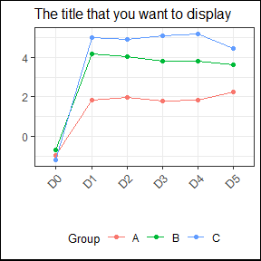

```r
g1=plot(tab1,title="The title that you want to display")
print(g1)
```

You can modify the plot by using the following arguments of the `plot.desc()` function:

```r
args(ClinReport:::plot.desc)
```

```
#> function (x, ..., title = "", ylim = NULL, xlim, xlab = "", ylab = "",
#>     legend.label = "Group", add.sd = F, add.ci = F, add.line = T)
#> NULL
```

Then we can use the `report.doc()` function which use the **flextable** package to format the output into a `flextable` object, ready to export to `Microsoft Word` with the **officer** package.

The table will look like this (we can have a preview in HTML, just to check):

```r
report.doc(tab1,title="Quantitative statistics (2 explicative variables)",
        colspan.value="Treatment group", init.numbering =T )
```

| Output 1: Quantitative statistics (2 explicative variables) TIMEPOINT | Output 1: Quantitative statistics (2 explicative variables) Statistics | Output 1: Quantitative statistics (2 explicative variables) Treatment group A (N=30) | Output 1: Quantitative statistics (2 explicative variables) Treatment group B (N=21) | Output 1: Quantitative statistics (2 explicative variables) Treatment group C (N=17) |
| --- | --- | --- | --- | --- |
| D0 | N | 30 | 20 | 16 |
|  | Mean (SD) | -0.93(0.86) | -0.67(1.09) | -1.19(0.92) |
|  | Median | -0.82 | -0.69 | -1.26 |
|  | [Q1;Q3] | [-1.59;-0.16] | [-1.39;-0.06] | [-1.62;-0.83] |
|  | [Min;Max] | [-2.34;0.36] | [-2.44;2.10] | [-2.99;0.66] |
|  | Missing | 1 | 1 | 0 |
| D1 | N | 30 | 20 | 16 |
|  | Mean (SD) | 1.83(1.04) | 4.17(1.28) | 4.98(0.69) |
|  | Median | 1.78 | 4.19 | 5.08 |
|  | [Q1;Q3] | [ 0.94; 2.54] | [ 3.23; 4.92] | [ 4.58; 5.46] |
|  | [Min;Max] | [ 0.11;3.88] | [ 1.48;6.19] | [ 3.80;6.23] |
|  | Missing | 1 | 0 | 0 |
| D2 | N | 30 | 20 | 16 |
|  | Mean (SD) | 1.97(1.17) | 4.04(0.89) | 4.90(1.36) |
|  | Median | 1.66 | 4.19 | 5.06 |
|  | [Q1;Q3] | [ 1.23; 2.86] | [ 3.62; 4.36] | [ 4.34; 5.20] |
|  | [Min;Max] | [-0.18;4.36] | [ 2.03;5.63] | [ 2.39;7.96] |
|  | Missing | 1 | 1 | 0 |
| D3 | N | 30 | 20 | 16 |
|  | Mean (SD) | 1.78(1.17) | 3.81(0.94) | 5.07(1.12) |
|  | Median | 1.78 | 3.63 | 5.22 |
|  | [Q1;Q3] | [ 0.93; 2.42] | [ 3.13; 4.44] | [ 4.11; 5.66] |
|  | [Min;Max] | [-0.16;3.90] | [ 2.46;6.01] | [ 3.16;7.37] |
|  | Missing | 0 | 1 | 1 |
| D4 | N | 30 | 20 | 16 |
|  | Mean (SD) | 1.83(0.85) | 3.80(0.95) | 5.17(1.03) |
|  | Median | 1.67 | 3.83 | 4.88 |
|  | [Q1;Q3] | [ 1.26; 2.32] | [ 3.12; 4.42] | [ 4.69; 5.50] |
|  | [Min;Max] | [ 0.38;3.97] | [ 2.31;5.41] | [ 3.24;6.96] |
|  | Missing | 1 | 1 | 1 |
| D5 | N | 30 | 20 | 16 |
|  | Mean (SD) | 2.27(1.20) | 3.64(1.19) | 4.43(0.98) |
|  | Median | 2.50 | 3.86 | 4.57 |
|  | [Q1;Q3] | [ 1.77; 3.21] | [ 2.59; 4.60] | [ 3.44; 4.97] |
|  | [Min;Max] | [-1.19;4.31] | [ 0.91;5.12] | [ 2.95;6.54] |
|  | Missing | 0 | 0 | 0 |

The `init.numbering` argument is used to specify that it’s the first output. After that, all output numbers will be increased automatically after each call of the function `report.doc()`.

Then, we add those results to a `rdocx` object:

```r
doc=read_docx()
doc=report.doc(tab1,title="Quantitative statistics (2 explicative variables)",
        colspan.value="Treatment group",doc=doc,init.numbering=T)
doc=body_add_gg(doc, value = g1, style = "centered" )
```

Write the doc to a docx file:

```r
file=paste(tempfile(),".docx",sep="")
print(doc, target =file)

#Open it
#shell.exec(file)
```

## The different outputs

### Qualitative tables

An example of qualitative statistics with one explicative variables

```r
tab=report.quali(data=data,y="y_logistic",
        x1="VAR",total=T,subjid="SUBJID")

report.doc(tab,title="Qualitative table with two variables",
colspan.value="A variable")
```

| Output 2: Qualitative table with two variables Levels | Output 2: Qualitative table with two variables Statistics | Output 2: Qualitative table with two variables A variable Cat 1 (N=65) | Output 2: Qualitative table with two variables A variable Cat 2 (N=63) | Output 2: Qualitative table with two variables Total (N=128) |
| --- | --- | --- | --- | --- |
| 0 | n (column %) | 100(48.08%) | 86(45.74%) | 186(46.97%) |
| 1 | n (column %) | 103(49.52%) | 97(51.60%) | 200(50.51%) |
|  | Missing n(%) | 5(2.40%) | 5(2.66%) | 10(2.53%) |

An example of qualitative statistics with two explicative variables

```r
tab=report.quali(data=data,y="y_logistic",
        x1="GROUP",x2="TIMEPOINT",at.row="TIMEPOINT",
        total=T,subjid="SUBJID")

report.doc(tab,title="Qualitative table with two variables",
colspan.value="Treatment group")
```

| Output 3: Qualitative table with two variables TIMEPOINT | Output 3: Qualitative table with two variables Levels | Output 3: Qualitative table with two variables Statistics | Output 3: Qualitative table with two variables Treatment group A (N=30) | Output 3: Qualitative table with two variables Treatment group B (N=21) | Output 3: Qualitative table with two variables Treatment group C (N=17) | Output 3: Qualitative table with two variables Total (N=68) |
| --- | --- | --- | --- | --- | --- | --- |
| D0 | 0 | n (column %) | 11(36.67%) | 11(55.00%) | 7(43.75%) | 29(43.94%) |
|  | 1 | n (column %) | 18(60.00%) | 8(40.00%) | 7(43.75%) | 33(50.00%) |
|  |  | Missing n(%) | 1(3.33%) | 1(5.00%) | 2(12.50%) | 4(6.06%) |
| D1 | 0 | n (column %) | 7(23.33%) | 13(65.00%) | 8(50.00%) | 28(42.42%) |
|  | 1 | n (column %) | 21(70.00%) | 7(35.00%) | 7(43.75%) | 35(53.03%) |
|  |  | Missing n(%) | 2(6.67%) | 0(0%) | 1(6.25%) | 3(4.55%) |
| D2 | 0 | n (column %) | 18(60.00%) | 7(35.00%) | 11(68.75%) | 36(54.55%) |
|  | 1 | n (column %) | 12(40.00%) | 13(65.00%) | 5(31.25%) | 30(45.45%) |
|  |  | Missing n(%) | 0(0%) | 0(0%) | 0(0%) | 0(0%) |
| D3 | 0 | n (column %) | 11(36.67%) | 10(50.00%) | 7(43.75%) | 28(42.42%) |
|  | 1 | n (column %) | 19(63.33%) | 10(50.00%) | 9(56.25%) | 38(57.58%) |
|  |  | Missing n(%) | 0(0%) | 0(0%) | 0(0%) | 0(0%) |
| D4 | 0 | n (column %) | 18(60.00%) | 12(60.00%) | 6(37.50%) | 36(54.55%) |
|  | 1 | n (column %) | 12(40.00%) | 8(40.00%) | 8(50.00%) | 28(42.42%) |
|  |  | Missing n(%) | 0(0%) | 0(0%) | 2(12.50%) | 2(3.03%) |
| D5 | 0 | n (column %) | 14(46.67%) | 7(35.00%) | 8(50.00%) | 29(43.94%) |
|  | 1 | n (column %) | 15(50.00%) | 13(65.00%) | 8(50.00%) | 36(54.55%) |
|  |  | Missing n(%) | 1(3.33%) | 0(0%) | 0(0%) | 1(1.52%) |

### Quantitative tables

An example of quantitative statistics with one explicative variables

```r
tab=report.quanti(data=data,y="y_numeric",
        x1="VAR",total=T,subjid="SUBJID")

report.doc(tab,title="Quantitative table with one explicative variable",
colspan.value="A variable")
```

| Output 4: Quantitative table with one explicative variable Statistics | Output 4: Quantitative table with one explicative variable A variable Cat 1 (N=65) | Output 4: Quantitative table with one explicative variable A variable Cat 2 (N=63) | Output 4: Quantitative table with one explicative variable Total (N=128) |
| --- | --- | --- | --- |
| N | 208 | 188 | 396 |
| Mean (SD) | 2.55(2.18) | 2.56(2.23) | 2.56(2.20) |
| Median | 2.64 | 2.79 | 2.71 |
| [Q1;Q3] | [0.94;4.36] | [1.07;4.19] | [1.04;4.33] |
| [Min;Max] | [-2.39;6.43] | [-2.99;7.96] | [-2.99;7.96] |
| Missing | 4 | 6 | 10 |

An example of quantitative statistics with two explicative variables

```r
tab=report.quanti(data=data,y="y_numeric",
        x1="GROUP",x2="TIMEPOINT",at.row="TIMEPOINT",
        total=T,subjid="SUBJID")

report.doc(tab,title="Quantitative table with two explicative variables",
colspan.value="Treatment group")
```

| Output 5: Quantitative table with two explicative variables TIMEPOINT | Output 5: Quantitative table with two explicative variables Statistics | Output 5: Quantitative table with two explicative variables Treatment group A (N=30) | Output 5: Quantitative table with two explicative variables Treatment group B (N=21) | Output 5: Quantitative table with two explicative variables Treatment group C (N=17) | Output 5: Quantitative table with two explicative variables Total (N=68) |
| --- | --- | --- | --- | --- | --- |
| D0 | N | 30 | 20 | 16 | 66 |
|  | Mean (SD) | -0.93(0.86) | -0.67(1.09) | -1.19(0.92) | -0.92(0.95) |
|  | Median | -0.82 | -0.69 | -1.26 | -0.86 |
|  | [Q1;Q3] | [-1.59;-0.16] | [-1.39;-0.06] | [-1.62;-0.83] | [-1.55;-0.16] |
|  | [Min;Max] | [-2.34;0.36] | [-2.44;2.10] | [-2.99;0.66] | [-2.99;2.10] |
|  | Missing | 1 | 1 | 0 | 2 |
| D1 | N | 30 | 20 | 16 | 66 |
|  | Mean (SD) | 1.83(1.04) | 4.17(1.28) | 4.98(0.69) | 3.33(1.73) |
|  | Median | 1.78 | 4.19 | 5.08 | 3.57 |
|  | [Q1;Q3] | [ 0.94; 2.54] | [ 3.23; 4.92] | [ 4.58; 5.46] | [ 1.78; 4.91] |
|  | [Min;Max] | [ 0.11;3.88] | [ 1.48;6.19] | [ 3.80;6.23] | [ 0.11;6.23] |
|  | Missing | 1 | 0 | 0 | 1 |
| D2 | N | 30 | 20 | 16 | 66 |
|  | Mean (SD) | 1.97(1.17) | 4.04(0.89) | 4.90(1.36) | 3.32(1.70) |
|  | Median | 1.66 | 4.19 | 5.06 | 3.57 |
|  | [Q1;Q3] | [ 1.23; 2.86] | [ 3.62; 4.36] | [ 4.34; 5.20] | [ 1.89; 4.44] |
|  | [Min;Max] | [-0.18;4.36] | [ 2.03;5.63] | [ 2.39;7.96] | [-0.18;7.96] |
|  | Missing | 1 | 1 | 0 | 2 |
| D3 | N | 30 | 20 | 16 | 66 |
|  | Mean (SD) | 1.78(1.17) | 3.81(0.94) | 5.07(1.12) | 3.15(1.75) |
|  | Median | 1.78 | 3.63 | 5.22 | 3.15 |
|  | [Q1;Q3] | [ 0.93; 2.42] | [ 3.13; 4.44] | [ 4.11; 5.66] | [ 1.80; 4.39] |
|  | [Min;Max] | [-0.16;3.90] | [ 2.46;6.01] | [ 3.16;7.37] | [-0.16;7.37] |
|  | Missing | 0 | 1 | 1 | 2 |
| D4 | N | 30 | 20 | 16 | 66 |
|  | Mean (SD) | 1.83(0.85) | 3.80(0.95) | 5.17(1.03) | 3.22(1.66) |
|  | Median | 1.67 | 3.83 | 4.88 | 3.16 |
|  | [Q1;Q3] | [ 1.26; 2.32] | [ 3.12; 4.42] | [ 4.69; 5.50] | [ 1.69; 4.48] |
|  | [Min;Max] | [ 0.38;3.97] | [ 2.31;5.41] | [ 3.24;6.96] | [ 0.38;6.96] |
|  | Missing | 1 | 1 | 1 | 3 |
| D5 | N | 30 | 20 | 16 | 66 |
|  | Mean (SD) | 2.27(1.20) | 3.64(1.19) | 4.43(0.98) | 3.21(1.45) |
|  | Median | 2.50 | 3.86 | 4.57 | 3.28 |
|  | [Q1;Q3] | [ 1.77; 3.21] | [ 2.59; 4.60] | [ 3.44; 4.97] | [ 2.42; 4.44] |
|  | [Min;Max] | [-1.19;4.31] | [ 0.91;5.12] | [ 2.95;6.54] | [-1.19;6.54] |
|  | Missing | 0 | 0 | 0 | 0 |

### Mixed Quantitative and Qualitative tables

You can mix qualitative and quantitative outputs.

But it’s only possible for 1 explicative variable, and it should be the same variable for both response:

```r
tab1=report.quanti(data=data,y="y_numeric",
        x1="GROUP",subjid="SUBJID",y.label="Y numeric")

tab2=report.quali(data=data,y="y_logistic",
        x1="GROUP",subjid="SUBJID",y.label="Y logistic")

tab3=regroup(tab1,tab2,rbind.label="The label of your choice")


report.doc(tab3,title="Mixed Qualitative and Quantitative output",
colspan.value="Treatment group")
```

| Output 6: Mixed Qualitative and Quantitative output The label of your choice | Output 6: Mixed Qualitative and Quantitative output Levels | Output 6: Mixed Qualitative and Quantitative output Treatment group Statistics | Output 6: Mixed Qualitative and Quantitative output Treatment group A (N=30) | Output 6: Mixed Qualitative and Quantitative output Treatment group B (N=21) | Output 6: Mixed Qualitative and Quantitative output Treatment group C (N=17) |
| --- | --- | --- | --- | --- | --- |
| Y logistic | 0 | n (column %) | 79(43.89%) | 60(50.00%) | 47(48.96%) |
|  | 1 | n (column %) | 97(53.89%) | 59(49.17%) | 44(45.83%) |
|  |  | Missing n(%) | 4(2.22%) | 1(0.83%) | 5(5.21%) |
| Y numeric |  | N | 180 | 120 | 96 |
|  |  | Mean (SD) | 1.46(1.50) | 3.15(2.00) | 3.87(2.52) |
|  |  | Median | 1.59 | 3.75 | 4.73 |
|  |  | [Q1;Q3] | [0.45;2.50] | [2.46;4.44] | [3.44;5.30] |
|  |  | [Min;Max] | [-2.34;4.36] | [-2.44;6.19] | [-2.99;7.96] |
|  |  | Missing | 4 | 4 | 2 |

### Anova model reporting

For the anova table reporting, it’s basically a call to the function `xtable_to_flextable()`. The function `report.doc()` just handle the numbering of the output and the header with the title.

```r
# Removing baseline data for the model
data.mod=droplevels(data[data$TIMEPOINT!="D0",])

mod=lme(y_numeric~baseline+GROUP+TIMEPOINT+GROUP*TIMEPOINT,
random=~1|SUBJID,data=data.mod,na.action=na.omit)

anov3=Anova(mod,3)

report.doc(anov3,title="Mixed Qualitative and Quantitative output")
```

| Output 7: Mixed Qualitative and Quantitative output | Output 7: Mixed Qualitative and Quantitative output Chisq | Output 7: Mixed Qualitative and Quantitative output Df | Output 7: Mixed Qualitative and Quantitative output Pr(>Chisq) |
| --- | --- | --- | --- |
| (Intercept) | 84.699 | 1.000 | 0.000 |
| baseline | 1.695 | 1.000 | 0.193 |
| GROUP | 107.561 | 2.000 | 0.000 |
| TIMEPOINT | 4.426 | 4.000 | 0.351 |
| GROUP:TIMEPOINT | 11.671 | 8.000 | 0.166 |

### LS-Means model reporting

LS-means reporting are based on the package **emmeans**. The function `report.lsmeans()` enables to format the output:

```r
lsm=emmeans(mod,~GROUP|TIMEPOINT)

tab=report.lsmeans(lsm,x1="GROUP",x2="TIMEPOINT",data=data.mod,
at.row="TIMEPOINT")

report.doc(tab,title="LS-Means example",
colspan.value="Treatment Group")
```

| Output 8: LS-Means example TIMEPOINT | Output 8: LS-Means example Statistics | Output 8: LS-Means example Treatment Group A | Output 8: LS-Means example Treatment Group B | Output 8: LS-Means example Treatment Group C |
| --- | --- | --- | --- | --- |
| D1 | Estimate (SE) | 1.81(0.20) | 4.17(0.24) | 5.00(0.27) |
|  | 95% CI | [1.41;2.22] | [3.69;4.65] | [4.46;5.54] |
|  | P-value | <0.001 | <0.001 | <0.001 |
| D2 | Estimate (SE) | 1.96(0.20) | 4.05(0.25) | 4.90(0.27) |
|  | 95% CI | [1.56;2.36] | [3.56;4.55] | [4.36;5.44] |
|  | P-value | <0.001 | <0.001 | <0.001 |
| D3 | Estimate (SE) | 1.79(0.20) | 3.79(0.25) | 5.08(0.28) |
|  | 95% CI | [1.39;2.18] | [3.29;4.28] | [4.52;5.63] |
|  | P-value | <0.001 | <0.001 | <0.001 |
| D4 | Estimate (SE) | 1.83(0.20) | 3.80(0.25) | 5.17(0.28) |
|  | 95% CI | [1.43;2.23] | [3.31;4.30] | [4.62;5.73] |
|  | P-value | <0.001 | <0.001 | <0.001 |
| D5 | Estimate (SE) | 2.28(0.20) | 3.64(0.24) | 4.42(0.27) |
|  | 95% CI | [1.89;2.68] | [3.15;4.12] | [3.88;4.96] |
|  | P-value | <0.001 | <0.001 | <0.001 |

### Pairs and Contrasts of LS-MEans

If you want to report contrast, you’ll have to specify `contrast=TRUE` in the call to `report.lsmeans()`.

```r
contr=contrast(lsm, "trt.vs.ctrl", ref = "A")

# Now there is just only one explicative variable
# since we make comparison between treatment group
# so there is only x1="TIMEPOINT" in the call

tab.contr=report.lsmeans(lsm=contr,x1="TIMEPOINT",
        data=data.mod,contrast=TRUE,at.row="contrast")


report.doc(tab.contr,title="LS-Means contrast example",
colspan.value="Time points")
```

| Output 9: LS-Means contrast example contrast | Output 9: LS-Means contrast example Statistics | Output 9: LS-Means contrast example Time points D1 | Output 9: LS-Means contrast example Time points D2 | Output 9: LS-Means contrast example Time points D3 | Output 9: LS-Means contrast example Time points D4 | Output 9: LS-Means contrast example Time points D5 |
| --- | --- | --- | --- | --- | --- | --- |
| B - A | Estimate (SE) | 2.36(0.31) | 2.10(0.32) | 2.00(0.32) | 1.97(0.32) | 1.35(0.31) |
|  | 95% CI | [1.66;3.06] | [1.38;2.81] | [1.29;2.71] | [1.26;2.68] | [0.66;2.05] |
|  | P-value | <0.001 | <0.001 | <0.001 | <0.001 | <0.001 |
| C - A | Estimate (SE) | 3.19(0.34) | 2.94(0.34) | 3.29(0.34) | 3.34(0.34) | 2.14(0.33) |
|  | 95% CI | [2.44;3.94] | [2.19;3.69] | [2.53;4.05] | [2.58;4.11] | [1.39;2.88] |
|  | P-value | <0.001 | <0.001 | <0.001 | <0.001 | <0.001 |